**Chapter 10: Dynamics of multiple populations**

## Overwiew

In most cases wildlife species are distributed across the landscape in multiple populations, and connectivity among individual populations may be as important as dynamics within them. Quantifying landscape connectivity and the cost of movement within a landscape has implications for species management and can guide corridor design in fragmented landscapes. In this exercise, we focus on computing resistance surface, and a landscape connectivity metric.

## Resistance surface

Let’s create a covariate of landscape features that potentially affects how animals move between locations. To do so, we can use functions from R spatial packages. Make sure they are loaded into the R environment before you continue.

First, we generate a 30 x 30 square covariate.

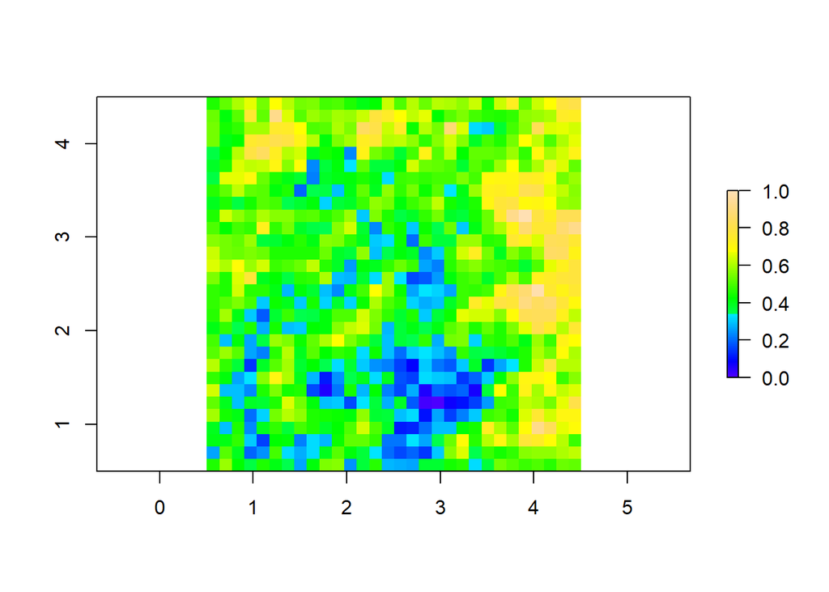

```r
library(raster)
library(rgeos)
library(rgdal)
library(gdistance)
library(igraph)
library(ggplot2)
library(RColorBrewer)

cell_size <- 30
r <- raster(nrows = cell_size, ncols = cell_size)
projection(r) <- "+proj=utm +zone=12 +datum=WGS84"
extent(r) <- c(0.5, 4.5, 0.5, 4.5)
delta <- (4.5 - 0.5) / cell_size
gx <- seq(0.5 + delta / 2, 4.5 - delta/2, , cell_size)
gy <- rev(gx)
gx <- sort(rep(gx, cell_size))
gy <- rep(gy, cell_size)
grid <- cbind(gx, gy)
d_mx <- as.matrix(dist(grid))
v <- exp(- d_mx / 0.5)
z <- t(chol(v)) %*% rnorm(cell_size * cell_size)
z <- (z - mean(z)) / sqrt(var(as.vector(z))) #
values(r) <- matrix(z, cell_size, cell_size, byrow = FALSE)
cov <- r
cov <-(cov - min(values(cov))) / (max(values(cov)) - min(values(cov))) #scale between 0 and 1
xy <- coordinates(cov)

par(mfrow = c(1, 1))
plot(cov, col = topo.colors(100))
```

The cost of moving from one cell to another varies between cells. To move across this landscape, individual animals would have to consider the least-cost path in addition to the Euclidean distance between two grid cells. That is, the pathway across the landsape with the lowest accumulated ecological cost or resistance to dispersal. Let’s compute the potential connectivity surface.

```r
sigma   <- 0.28
a2      <- 1.25
a1      <- 1/(2 * sigma * sigma)
a0      <- 1
xy      <- raster::coordinates(cov)

# estimate cost surface based on covariate
cost    <- exp(a2 * cov)
# transition function transforms cost to conductance
tr_out  <- gdistance::transition(cost,
                                 transitionFunction = function(x)(1 / (mean(x))),
                                 directions = 16)
tr_out  <- gdistance::geoCorrection(tr_out, type = "c", multpl = F, scl = F)
dmat    <- gdistance::costDistance(tr_out, xy, xy)
# encounter model with a0 = 1 and cost-weighted distance
potmat  <- 1 * exp(-a1 * dmat * dmat)
```

For a given individual home range located at cell 200, e.g., i = 200, the probability of using one cell is divided by the sum of probabilities. This is known as utilization distribution. We can compute the potential connectivity surface for any given individual home range location, and identify grid cells with more than 95% utilization.

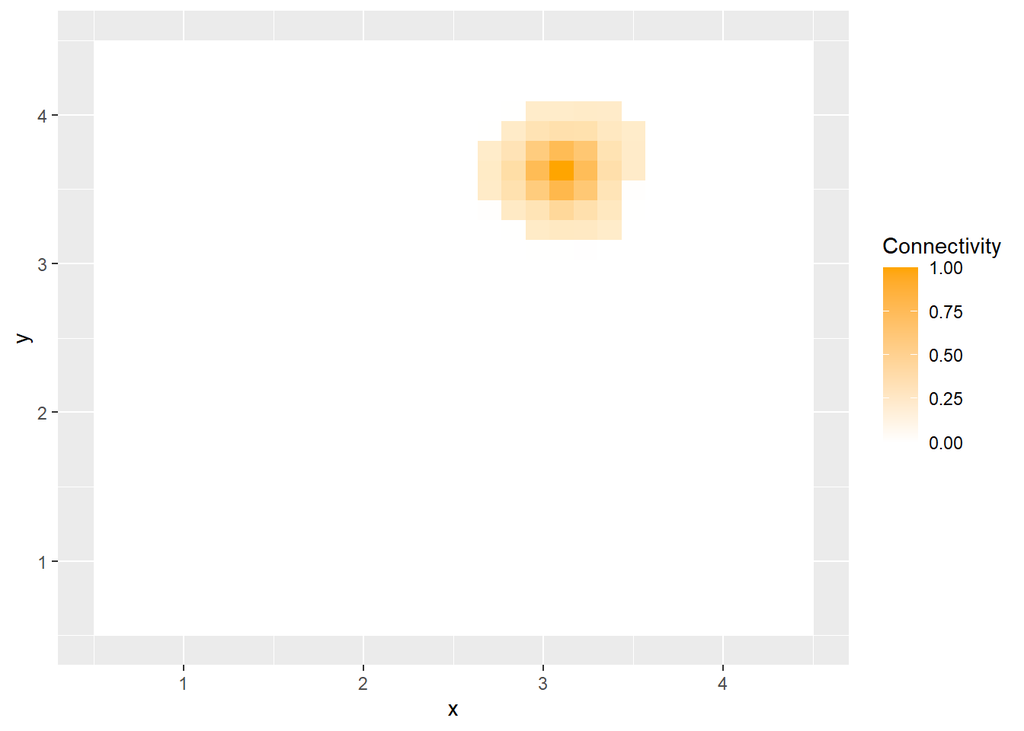

```r
i <- 200
potential_c <- data.frame(x = xy[, 1],
                          y = xy[, 2],
                          Connectivity = potmat[i, ])

pix <- data.frame(x = xy[,1],
                  y = xy[,2],
                  UD = 0)
pix$UD[which(potmat[i,] > (0.95 * (sum(potmat[i, ])) / raster::ncell(cov)))] <- 1


# Plot the potential connectivity for one home range
ggplot() +
  geom_raster(potential_c, mapping = aes(x = x, y = y, fill = Connectivity)) +
  geom_raster(pix, mapping = aes(x = x, y = y, fill = UD), alpha = 0.2) +
  scale_fill_gradient2(low = "white", mid = "white" , high = "orange")
```

**Practice:**

1. You may have noticed two distance functions, i.e, two different equations for calculating distance in this tutorial. Compare the two pairwise matrices by visualizing in two histograms. Is detection probability affected by detection calculation?

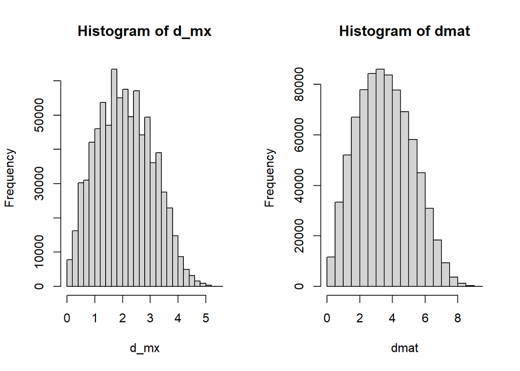

```r
d_mx[1:10,1:10]            # a subset of the Euclidean distance between cells
dmat[1:10, 1:10]           # a subset of the non-Euclidean distance bw cells

p_euc  <- 1 * exp( - a1 * d_mx * d_mx)
p_neuc <- 1 * exp( - a1 * dmat * dmat)

par(mfrow = c(1,2))
hist(d_mx)
hist(dmat)
```

2. Compute the potential connectivity for a few more individual home ranges. Looking at the covariate, do you see different costs associated with moving within a home range?

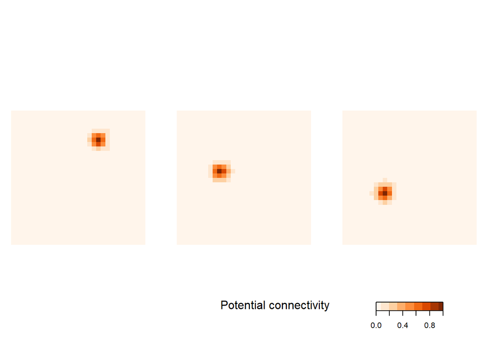

```r
ac <- c(200, 400, 550)

par(mfrow = c(1,3), mar = c(0, 1.2, 0, 0))
for(i in 1 : length(ac)) {
  this_ac <- ac[i]
  df <- data.frame(x = xy[, 1],
                   y = xy[, 2],
                   Connectivity = potmat[this_ac, ])

  # create spatial points data frame
  potential_c <- df
  coordinates(potential_c) <- ~ x + y
  # coerce to SpatialPixelsDataFrame
  gridded(potential_c) <- TRUE
  # coerce to raster
  pc_raster <- raster(potential_c)

  plot(pc_raster,
       col    = brewer.pal("Oranges", n = 99),
       axes   = FALSE,
       legend = FALSE,
       box    = FALSE)
}

plot(pc_raster,
     col = brewer.pal("Oranges", n = 99) ,
     legend.only = TRUE,
     horizontal = TRUE, xpd = NA,
     legend.args = list(text = "Potential connectivity", side = 1, line = -1, at = -1.5))
```